# Short term effects

# Preparations

## Install packages

```r
rm(list=ls())

if(!require("pacman")) install.packages("pacman"); library(pacman)
p_load(here,
       terra)
```

## Load required data

TOC data are loaded as weight-% and converted to a dimensionless fraction to simplify equations. Dry bulk density data are loaded as g per cm3 and converted to kg per m3 for the same reason.

```r
# Organic carbon content in the surface layer
date <- list.files(path = here("toc_model", "data", "final"), pattern = "OC_sf_median_")
date <- sub(".*?OC_sf_median_(.*?).tif*", "\\1", date)
date <- as.Date(date)
date <- max(date)
TOC_sf <- rast(here("toc_model", "data", "final", paste0("OC_sf_median_", date, ".tif")))
TOC_sf <- TOC_sf/100

# Dry bulk density in the surface layer
date <- list.files(path = here("dbd_model", "data", "final"), pattern = "DBD_sf_median_")
date <- sub(".*?DBD_sf_median_(.*?).tif*", "\\1", date)
date <- as.Date(date)
date <- max(date)
DBD_sf <- rast(here("dbd_model", "data", "final", paste0("DBD_sf_median_", date, ".tif")))
DBD_sf <- DBD_sf * 1000

# Carbon reactivity index
date <- list.files(path = here("cri_model", "data", "final"), pattern = "CRI_median_")
date <- sub(".*?CRI_median_(.*?).tif*", "\\1", date)
date <- as.Date(date)
date <- max(date)
CRI <- rast(here("cri_model", "data", "final", paste0("CRI_median_", date, ".tif")))

# Surface swept area ratio
SAR_sf_beam <- rast(here("fishing_data", "data", "final", "sar_mean_Beam_2009to2020.tif"))
SAR_sf_otter <- rast(here("fishing_data", "data", "final", "sar_mean_Otter_2009to2020.tif"))
SAR_sf_seine <- rast(here("fishing_data", "data", "final", "sar_mean_Seine_2009to2020.tif"))
```

# Labile organic carbon stock (kg/m2) of the surface layer (0 - 2 cm)

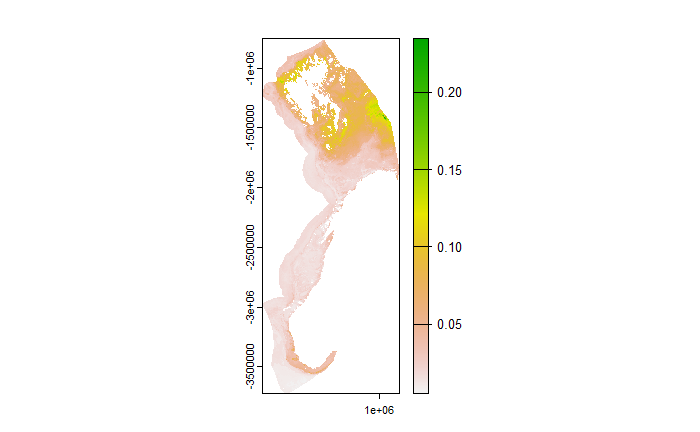

```r
locs_sf <- DBD_sf * TOC_sf * (1 - CRI) * 0.02
plot(locs_sf)
```

## Calculate labile organic carbon pool (Tg)

```r
A <- res(TOC_sf)[1]*res(TOC_sf)[2] #Area of one pixel

locp_sf <- as.numeric(global(locs_sf, sum, na.rm = TRUE)*A/1000000000)
```

# Swept volume ratio

## Gear penetration depths (cm)

Average gear penetration depths are taken from Hiddink et al. (2017)[https://doi.org/10.1073/pnas.1618858114] for beam and otter trawlers. The value for seines is a conservative estimate by Epstein & Roberts (2022)[https://doi.org/10.1371/journal.pclm.0000059] based on Eigaard et al. (2016)[https://doi.org/10.1093/icesjms/fsv099].

```r
d_beam <- 2.72
d_otter <- 2.44
d_seine <- 0.5
```

## Calculate swept volume ratios (SVR)

```r
SVR_sf_beam <- SAR_sf_beam * ifelse(d_beam <= 2, d_beam/2, 1)
SVR_sf_otter <- SAR_sf_otter * ifelse(d_otter <= 2, d_otter/2, 1)
SVR_sf_seine <- SAR_sf_seine * ifelse(d_seine <= 2, d_seine/2, 1)

SVR_sf <- SVR_sf_beam + SVR_sf_otter + SVR_sf_seine
```

## Project SVR data

```r
SVR_sf_pr <- project(SVR_sf, TOC_sf)
```

# Disturbed labile organic carbon

## Disturbed labile organic carbon stock (kg/m2)

This is a value of annual cumulative disturbance of labile organic carbon stocks following Epstein & Roberts (2022)[https://doi.org/10.1371/journal.pclm.0000059]. Note that disturbed and undisturbed labile organic carbon (below) pools do not sum up to the labile organic carbon pool.

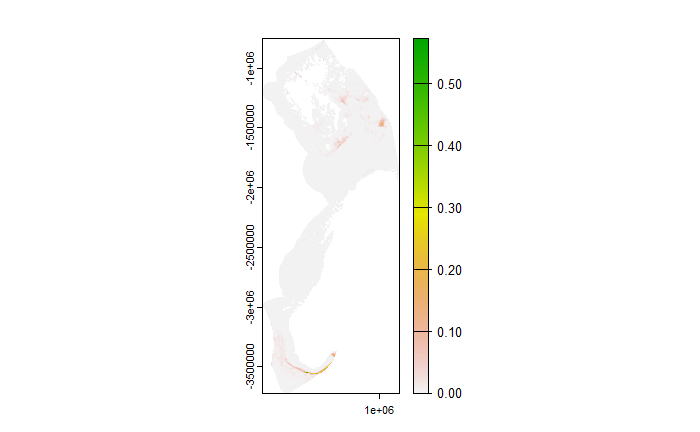

```r
locs_sf_dist <- locs_sf * SVR_sf_pr

plot(locs_sf_dist)
```

## Calculate disturbed labile organic carbon pool (Tg)

```r
locp_sf_dist <- as.numeric(global(locs_sf_dist, sum, na.rm = TRUE)*A/1000000000)
```

# Undisturbed labile organic carbon

## Unfished areas

Create a mask of unfished areas, i.e., all grid cells that have a SVR = 0.

```r
unfished <- SVR_sf
unfished[unfished != 0] <- NA
unfished[unfished == 0] <- 1
unfished <- project(unfished, TOC_sf, method = "near")
```

## Undisturbed labile organic carbon stock (kg/m2)

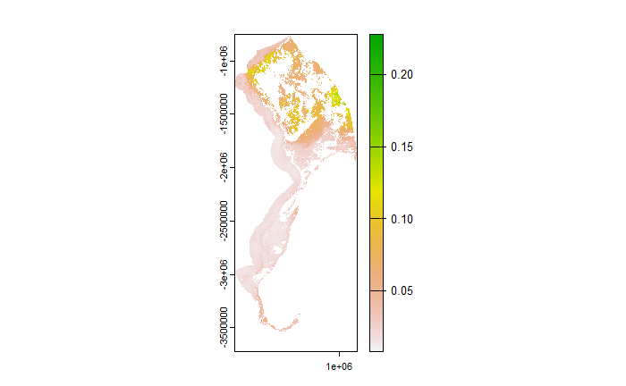

```r
locs_sf_undist <- locs_sf * unfished

plot(locs_sf_undist)
```

## Calculate undisturbed labile organic carbon pool (Tg)

```r
locp_sf_undist <- as.numeric(global(locs_sf_undist, sum, na.rm = TRUE)*A/1000000000)
```

# Vulnerable labile organic carbon

Chlorophyll-a and phaeopigments have been used as tracers of labile organic carbon (Stephens et al., 1997)[https://doi.org/10.1016/S0016-7037(97)00358-X]. However, chlorophyll-a might be too labile to test differences in organic matter related to trawling (Sañé et al., 2013)[https://doi.org/10.5194/bg-10-8093-2013].

## Meta-analysis results

Analysis as in Tiano et al. (2024)[https://doi.org/10.1111/faf.12855] but restricted to surface layer and acute impacts (first week after fishing event). Does also include additional studies and variables. Estimates are reported as log response ratio (lnRR).

```r
effect_size <- read.csv(here("analysis", "data", "raw", "surface_layer.csv"))
effect_size
```

| Variable | lnRR | SE | p.value | CI.lb | CI.ub | N |
| --- | --- | --- | --- | --- | --- | --- |
| TOC | -0.147 | 0.043 | 7e-04 | -0.2320 | -0.063 | 23 |
| Chl-a | -0.340 | 0.119 | 4e-03 | -0.5740 | -0.106 | 18 |
| Phaeopigments | -0.316 | 0.093 | 1e-03 | -0.4970 | -0.134 | 11 |
| DBD | 0.162 | 0.090 | 7e-02 | -0.0145 | 0.339 | 7 |
| DBD incl. 3 studies with n=1 | 0.246 | 0.113 | 3e-02 | 0.0250 | 0.467 | 10 |

## Calculate effect sizes

```r
#Phaeopigments
phaeo_sf_effect_mean <- exp(effect_size[3,2])-1
phaeo_sf_effect_lower <- exp(effect_size[3,5])-1
phaeo_sf_effect_upper <- exp(effect_size[3,6])-1

#Dry bulk density
dbd_sf_effect_mean <- exp(effect_size[5,2])-1
dbd_sf_effect_lower <- exp(effect_size[5,5])-1
dbd_sf_effect_upper <- exp(effect_size[5,6])-1
```

## Calculate vulnerable labile organic carbon (kg/m2)

Vulnerable labile organic carbon is defined here as the carbon that would be lost due to trawling a grid cell once completely and evenly over the full depth of the surface layer (SVR = 1).

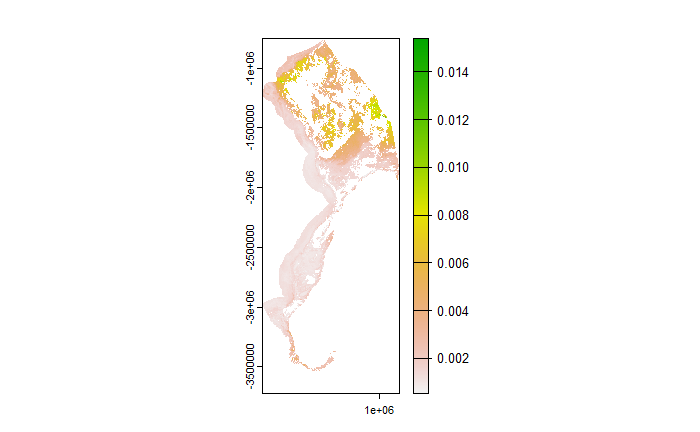

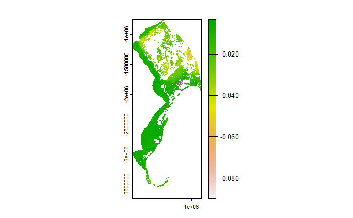

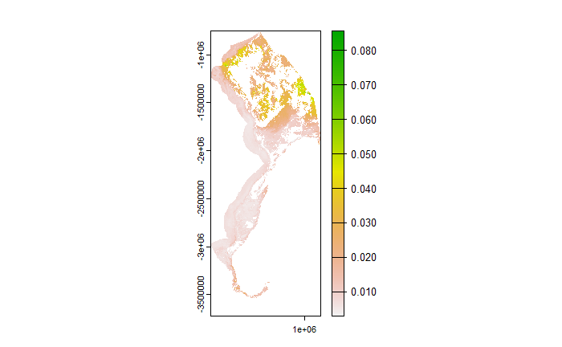

```r
plot(locs_sf_vuln_mean)
plot(locs_sf_vuln_low)

plot(locs_sf_vuln_high)
```

## Based on meta-regression with surface primary productivity

### Surface primary productivity data (g m-3 d-1)

Data from Bio-ORACLE v2.2

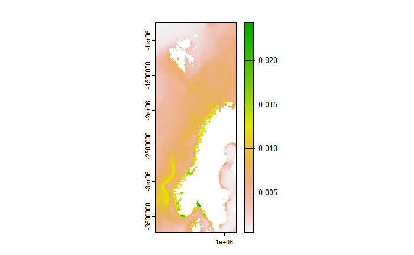

```r
PP <- rast(here("analysis", "data", "raw", "Present.Surface.Primary.productivity.Mean.tif"))
PP <- project(PP, locs_sf_undist)
plot(PP)
```

### Meta-regression

Data are taken from Tiano et al. (2024)[https://doi.org/10.1111/faf.12855] Table S8.

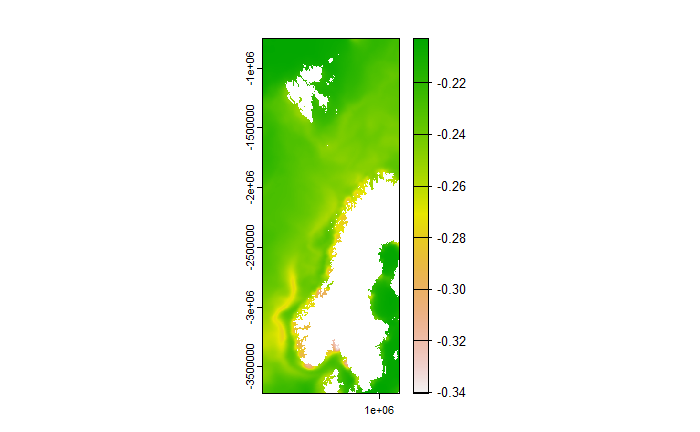

```r
lnRR_phaeo_sf <- -7.953 * PP -0.223
phaeo_sf_effect_regr <- exp(lnRR_phaeo_sf)-1
plot(phaeo_sf_effect_regr)
```

### Calculate vulnerable labile organic carbon from meta-regression

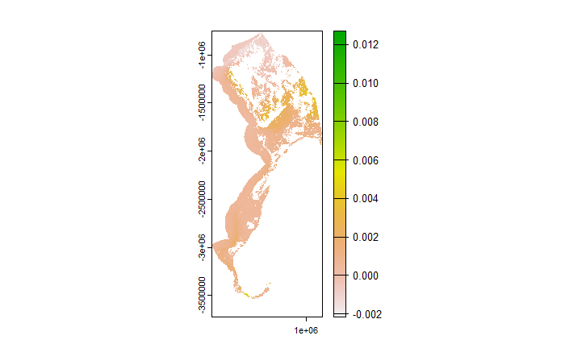

```r
locs_sf_vuln_regr <- locs_sf_undist - (DBD_sf * (1 + dbd_sf_effect_mean) * TOC_sf * (1 - CRI) * (1 + phaeo_sf_effect_regr) * 0.02 * svr)

plot(locs_sf_vuln_regr)
```

## Calculate vulnerable labile organic carbon pools (Tg)

```r
locp_sf_vuln_mean <- as.numeric(global(locs_sf_vuln_mean, sum, na.rm = TRUE)*A/1000000000)
locp_sf_vuln_low <- as.numeric(global(locs_sf_vuln_low, sum, na.rm = TRUE)*A/1000000000)
locp_sf_vuln_high <- as.numeric(global(locs_sf_vuln_high, sum, na.rm = TRUE)*A/1000000000)
locp_sf_vuln_regr <- as.numeric(global(locs_sf_vuln_regr, sum, na.rm = TRUE)*A/1000000000)
```

# Output raster

```r
writeRaster(locs_sf, here("analysis", "data", "final", "LOC_stock_sf.tif"), overwrite = TRUE)
writeRaster(locs_sf_dist, here("analysis", "data", "final", "LOC_stock_sf_disturbed.tif"), overwrite = TRUE)
writeRaster(locs_sf_undist, here("analysis", "data", "final", "LOC_stock_sf_undisturbed.tif"), overwrite = TRUE)
writeRaster(locs_sf_vuln_mean, here("analysis", "data", "final", "LOC_stock_sf_vulnerable_mean.tif"), overwrite = TRUE)
writeRaster(locs_sf_vuln_low, here("analysis", "data", "final", "LOC_stock_sf_vulnerable_low.tif"), overwrite = TRUE)
writeRaster(locs_sf_vuln_high, here("analysis", "data", "final", "LOC_stock_sf_vulnerable_high.tif"), overwrite = TRUE)
writeRaster(locs_sf_vuln_regr, here("analysis", "data", "final", "LOC_stock_sf_vulnerable_regr.tif"), overwrite = TRUE)
```